# Sesion 3 | Part 2 : Gene expression analysis

Jonathan Maldonado 06/03/2020

Following the former pipeline, we were able to obtain a table with read counts per gene of Arabidopsis. That table was generated using the reduced version of the original sequencing files. For this pipeline, we will use a similar file, containing gene counts obtained from the analysis of the original .fastq files.

Open R Studio (or just R) and load the following libraries. Load each library **one at a time** to be sure that the library is installed on your system. Otherwise, remember to use BiocManager::install(“packagename”).

```r
library(edgeR)
library(knitr)
library(dplyr)
library(pvclust)
library(ggplot2)
require(gridExtra)
library(RColorBrewer)
library(mixOmics)
library(reshape2)
library(gplots)
library(mclust)
library(matrixStats)
```

Don’t forget to set the working directory right were your downloaded files are.

```r
setwd("~/iBio/workshop2020-iBio/S1")
```

## 1. Importing and formatting data

Start importing counts table and metadata associated to the samples (previously downloaded from Data folder).

```r
counts <- read.table("fc0.counts_original.txt")
metadata <- read.table("metadata.txt", header=TRUE)
kable(head(metadata))
```

| Sample | Tissue | Treatment | Replicate | Time |
| --- | --- | --- | --- | --- |
| SRR5440784 | Shoot | None | 1 | 0 |
| SRR5440785 | Shoot | None | 2 | 0 |
| SRR5440786 | Shoot | None | 3 | 0 |
| SRR5440814 | Shoot | None | 1 | 5 |
| SRR5440815 | Shoot | None | 1 | 10 |
| SRR5440816 | Shoot | None | 1 | 15 |

We will fix the header of counts leaving only the sample ID.

```r
colnames(counts) <- sapply(strsplit(colnames(counts),".",fixed=TRUE), `[`, 1)
kable(head(counts))
```

|  | SRR5440784 | SRR5440785 | SRR5440786 | SRR5440814 | SRR5440815 | SRR5440816 | SRR5440817 | SRR5440818 | SRR5440819 | SRR5440820 | SRR5440821 | SRR5440822 | SRR5440823 | SRR5440824 | SRR5440825 | SRR5440826 | SRR5440827 | SRR5440828 | SRR5440829 | SRR5440830 | SRR5440831 | SRR5440832 | SRR5440833 | SRR5440834 | SRR5440835 | SRR5440836 | SRR5440837 | SRR5440838 | SRR5440839 | … |
| --- | --- | --- | --- | --- | --- | --- | --- | --- | --- | --- | --- | --- | --- | --- | --- | --- | --- | --- | --- | --- | --- | --- | --- | --- | --- | --- | --- | --- | --- | --- |
| AT1G01010 | 1040 | 1512 | 1162 | 517 | 379 | 440 | 279 | 384 | 362 | 421 | 221 | 265 | 339 | 406 | 597 | 394 | 367 | 263 | 307 | 379 | 283 | 369 | 296 | 588 | 258 | 383 | 265 | 400 | 199 | … |
| AT1G01020 | 376 | 722 | 679 | 206 | 226 | 213 | 291 | 244 | 224 | 209 | 327 | 260 | 260 | 197 | 368 | 217 | 168 | 171 | 178 | 340 | 277 | 225 | 206 | 282 | 103 | 222 | 243 | 267 | 201 | … |
| AT1G03987 | 1 | 0 | 4 | 0 | 1 | 0 | 1 | 0 | 0 | 0 | 0 | 0 | 0 | 0 | 1 | 1 | 0 | 1 | 0 | 0 | 0 | 0 | 1 | 0 | 0 | 0 | 0 | 0 | 0 | … |
| AT1G01030 | 116 | 195 | 179 | 51 | 60 | 55 | 48 | 55 | 37 | 60 | 65 | 45 | 77 | 56 | 81 | 32 | 42 | 32 | 33 | 58 | 49 | 85 | 60 | 78 | 50 | 50 | 37 | 43 | 23 | … |
| AT1G01040 | 3931 | 6002 | 5513 | 1418 | 1503 | 1436 | 1415 | 1787 | 1571 | 2006 | 1340 | 1413 | 1702 | 1382 | 2453 | 1369 | 1388 | 1365 | 1257 | 1622 | 1458 | 1737 | 1384 | 2240 | 983 | 1627 | 1346 | 1833 | 1174 | … |
| AT1G03993 | 327 | 564 | 513 | 94 | 94 | 81 | 38 | 106 | 109 | 155 | 65 | 82 | 111 | 116 | 182 | 75 | 65 | 122 | 65 | 101 | 98 | 105 | 67 | 151 | 89 | 108 | 73 | 143 | 80 | … |

This is a time-series data so, it would be good that samples order follows the time-series.

```r
metadata <- metadata %>% arrange(Time)
counts <- counts[,metadata$Sample]
dim(counts)
```

```
## [1] 32833    30
```

> This table has 30 samples and 32,833 genes.

## 2. Creating the edgeR object

To create the edgeR object we need the counts. Optionally we can group samples by a factor. We will group samples by time.

```r
dgList <- DGEList(counts=counts, genes=rownames(counts), group=metadata$Time)
```

Take a look to the created object. It contains data for $counts, $samples and $genes.

```r
dgList
```

```
## An object of class "DGEList"
## $counts
##           SRR5440784 SRR5440785 SRR5440786 SRR5440814 SRR5440823 SRR5440832
## AT1G01010       1040       1512       1162        517        339        369
## AT1G01020        376        722        679        206        260        225
## AT1G03987          1          0          4          0          0          0
## AT1G01030        116        195        179         51         77         85
## AT1G01040       3931       6002       5513       1418       1702       1737
##           SRR5440815 SRR5440824 SRR5440833 SRR5440816 SRR5440825 SRR5440834
## AT1G01010        379        406        296        440        597        588
## AT1G01020        226        197        206        213        368        282
## AT1G03987          1          0          1          0          1          0
## AT1G01030         60         56         60         55         81         78
## AT1G01040       1503       1382       1384       1436       2453       2240
##           SRR5440817 SRR5440826 SRR5440835 SRR5440818 SRR5440827 SRR5440836
## AT1G01010        279        394        258        384        367        383
## AT1G01020        291        217        103        244        168        222
## AT1G03987          1          1          0          0          0          0
## AT1G01030         48         32         50         55         42         50
## AT1G01040       1415       1369        983       1787       1388       1627
##           SRR5440819 SRR5440828 SRR5440837 SRR5440820 SRR5440829 SRR5440838
## AT1G01010        362        263        265        421        307        400
## AT1G01020        224        171        243        209        178        267
## AT1G03987          0          1          0          0          0          0
## AT1G01030         37         32         37         60         33         43
## AT1G01040       1571       1365       1346       2006       1257       1833
##           SRR5440821 SRR5440830 SRR5440839 SRR5440822 SRR5440831 SRR5440840
## AT1G01010        221        379        199        265        283        487
## AT1G01020        327        340        201        260        277        370
## AT1G03987          0          0          0          0          0          0
## AT1G01030         65         58         23         45         49         61
## AT1G01040       1340       1622       1174       1413       1458       2119
## 32828 more rows ...
##
## $samples
##            group lib.size norm.factors
## SRR5440784     0 41320115            1
## SRR5440785     0 60926929            1
## SRR5440786     0 62461021            1
## SRR5440814     5 17293869            1
## SRR5440823     5 18728454            1
## 25 more rows ...
##
## $genes
##               genes
## AT1G01010 AT1G01010
## AT1G01020 AT1G01020
## AT1G03987 AT1G03987
## AT1G01030 AT1G01030
## AT1G01040 AT1G01040
## 32828 more rows ...
```

A more detailed view on $samples will show you that they are grouped, as expected.

```r
kable(dgList$samples)
```

|  | group | lib.size | norm.factors |
| --- | --- | --- | --- |
| SRR5440784 | 0 | 41320115 | 1 |
| SRR5440785 | 0 | 60926929 | 1 |
| SRR5440786 | 0 | 62461021 | 1 |
| SRR5440814 | 5 | 17293869 | 1 |
| SRR5440823 | 5 | 18728454 | 1 |
| SRR5440832 | 5 | 17873947 | 1 |
| SRR5440815 | 10 | 14054914 | 1 |
| SRR5440824 | 10 | 14086206 | 1 |
| SRR5440833 | 10 | 14027534 | 1 |
| SRR5440816 | 15 | 16583433 | 1 |
| SRR5440825 | 15 | 24783195 | 1 |
| SRR5440834 | 15 | 22452928 | 1 |
| SRR5440817 | 20 | 14582449 | 1 |
| SRR5440826 | 20 | 15257306 | 1 |
| SRR5440835 | 20 | 10146285 | 1 |
| SRR5440818 | 30 | 18398967 | 1 |
| SRR5440827 | 30 | 14846112 | 1 |
| SRR5440836 | 30 | 16928897 | 1 |
| SRR5440819 | 45 | 16571707 | 1 |
| SRR5440828 | 45 | 14868446 | 1 |
| SRR5440837 | 45 | 17898490 | 1 |
| SRR5440820 | 60 | 24313190 | 1 |
| SRR5440829 | 60 | 18276065 | 1 |
| SRR5440838 | 60 | 22102526 | 1 |
| SRR5440821 | 90 | 20396516 | 1 |
| SRR5440830 | 90 | 23416756 | 1 |
| SRR5440839 | 90 | 15149483 | 1 |
| SRR5440822 | 120 | 21133063 | 1 |
| SRR5440831 | 120 | 18059122 | 1 |
| SRR5440840 | 120 | 27663285 | 1 |

```r
kable(head(dgList$counts)) # segment of the table
```

|  | SRR5440784 | SRR5440785 | SRR5440786 | SRR5440814 | SRR5440823 | SRR5440832 | SRR5440815 | SRR5440824 | SRR5440833 | SRR5440816 | SRR5440825 | SRR5440834 | SRR5440817 | SRR5440826 | SRR5440835 | SRR5440818 | SRR5440827 | SRR5440836 | SRR5440819 | SRR5440828 | SRR5440837 | SRR5440820 | SRR5440829 | SRR5440838 | SRR5440821 | SRR5440830 | SRR5440839 | SRR5440822 | SRR5440831 | … |
| --- | --- | --- | --- | --- | --- | --- | --- | --- | --- | --- | --- | --- | --- | --- | --- | --- | --- | --- | --- | --- | --- | --- | --- | --- | --- | --- | --- | --- | --- | --- |
| AT1G01010 | 1040 | 1512 | 1162 | 517 | 339 | 369 | 379 | 406 | 296 | 440 | 597 | 588 | 279 | 394 | 258 | 384 | 367 | 383 | 362 | 263 | 265 | 421 | 307 | 400 | 221 | 379 | 199 | 265 | 283 | … |
| AT1G01020 | 376 | 722 | 679 | 206 | 260 | 225 | 226 | 197 | 206 | 213 | 368 | 282 | 291 | 217 | 103 | 244 | 168 | 222 | 224 | 171 | 243 | 209 | 178 | 267 | 327 | 340 | 201 | 260 | 277 | … |
| AT1G03987 | 1 | 0 | 4 | 0 | 0 | 0 | 1 | 0 | 1 | 0 | 1 | 0 | 1 | 1 | 0 | 0 | 0 | 0 | 0 | 1 | 0 | 0 | 0 | 0 | 0 | 0 | 0 | 0 | 0 | … |
| AT1G01030 | 116 | 195 | 179 | 51 | 77 | 85 | 60 | 56 | 60 | 55 | 81 | 78 | 48 | 32 | 50 | 55 | 42 | 50 | 37 | 32 | 37 | 60 | 33 | 43 | 65 | 58 | 23 | 45 | 49 | … |
| AT1G01040 | 3931 | 6002 | 5513 | 1418 | 1702 | 1737 | 1503 | 1382 | 1384 | 1436 | 2453 | 2240 | 1415 | 1369 | 983 | 1787 | 1388 | 1627 | 1571 | 1365 | 1346 | 2006 | 1257 | 1833 | 1340 | 1622 | 1174 | 1413 | 1458 | … |
| AT1G03993 | 327 | 564 | 513 | 94 | 111 | 105 | 94 | 116 | 67 | 81 | 182 | 151 | 38 | 75 | 89 | 106 | 65 | 108 | 109 | 122 | 73 | 155 | 65 | 143 | 65 | 101 | 80 | 82 | 98 | … |

We can add metadata to the edgeR object to use it directly

```r
dgList$metadata <- metadata
```

Now, take a look to the object and you will see a new variable called $metadata at the end

```r
dgList
```

```
## An object of class "DGEList"
## $counts
##           SRR5440784 SRR5440785 SRR5440786 SRR5440814 SRR5440823 SRR5440832
## AT1G01010       1040       1512       1162        517        339        369
## AT1G01020        376        722        679        206        260        225
## AT1G03987          1          0          4          0          0          0
## AT1G01030        116        195        179         51         77         85
## AT1G01040       3931       6002       5513       1418       1702       1737
##           SRR5440815 SRR5440824 SRR5440833 SRR5440816 SRR5440825 SRR5440834
## AT1G01010        379        406        296        440        597        588
## AT1G01020        226        197        206        213        368        282
## AT1G03987          1          0          1          0          1          0
## AT1G01030         60         56         60         55         81         78
## AT1G01040       1503       1382       1384       1436       2453       2240
##           SRR5440817 SRR5440826 SRR5440835 SRR5440818 SRR5440827 SRR5440836
## AT1G01010        279        394        258        384        367        383
## AT1G01020        291        217        103        244        168        222
## AT1G03987          1          1          0          0          0          0
## AT1G01030         48         32         50         55         42         50
## AT1G01040       1415       1369        983       1787       1388       1627
##           SRR5440819 SRR5440828 SRR5440837 SRR5440820 SRR5440829 SRR5440838
## AT1G01010        362        263        265        421        307        400
## AT1G01020        224        171        243        209        178        267
## AT1G03987          0          1          0          0          0          0
## AT1G01030         37         32         37         60         33         43
## AT1G01040       1571       1365       1346       2006       1257       1833
##           SRR5440821 SRR5440830 SRR5440839 SRR5440822 SRR5440831 SRR5440840
## AT1G01010        221        379        199        265        283        487
## AT1G01020        327        340        201        260        277        370
## AT1G03987          0          0          0          0          0          0
## AT1G01030         65         58         23         45         49         61
## AT1G01040       1340       1622       1174       1413       1458       2119
## 32828 more rows ...
##
## $samples
##            group lib.size norm.factors
## SRR5440784     0 41320115            1
## SRR5440785     0 60926929            1
## SRR5440786     0 62461021            1
## SRR5440814     5 17293869            1
## SRR5440823     5 18728454            1
## 25 more rows ...
##
## $genes
##               genes
## AT1G01010 AT1G01010
## AT1G01020 AT1G01020
## AT1G03987 AT1G03987
## AT1G01030 AT1G01030
## AT1G01040 AT1G01040
## 32828 more rows ...
##
## $metadata
##       Sample Tissue Treatment Replicate Time
## 1 SRR5440784  Shoot      None         1    0
## 2 SRR5440785  Shoot      None         2    0
## 3 SRR5440786  Shoot      None         3    0
## 4 SRR5440814  Shoot      None         1    5
## 5 SRR5440823  Shoot      None         2    5
## 25 more rows ...
```

Samples names are not informative. Let’s transform them to a more informative form.

Set a vector with the new names and apply them to our data

```r
ColRename <- paste(paste0(rep("t",30),dgList$metadata[,"Time"]),paste0(rep("r",30),dgList$metadata[,"Replicate"]),sep=".")
colnames(dgList) <- ColRename
```

Now, review your new names

```r
dgList$samples
```

```
##         group lib.size norm.factors
## t0.r1       0 41320115            1
## t0.r2       0 60926929            1
## t0.r3       0 62461021            1
## t5.r1       5 17293869            1
## t5.r2       5 18728454            1
## t5.r3       5 17873947            1
## t10.r1     10 14054914            1
## t10.r2     10 14086206            1
## t10.r3     10 14027534            1
## t15.r1     15 16583433            1
## t15.r2     15 24783195            1
## t15.r3     15 22452928            1
## t20.r1     20 14582449            1
## t20.r2     20 15257306            1
## t20.r3     20 10146285            1
## t30.r1     30 18398967            1
## t30.r2     30 14846112            1
## t30.r3     30 16928897            1
## t45.r1     45 16571707            1
## t45.r2     45 14868446            1
## t45.r3     45 17898490            1
## t60.r1     60 24313190            1
## t60.r2     60 18276065            1
## t60.r3     60 22102526            1
## t90.r1     90 20396516            1
## t90.r2     90 23416756            1
## t90.r3     90 15149483            1
## t120.r1   120 21133063            1
## t120.r2   120 18059122            1
## t120.r3   120 27663285            1
```

## 3. Data normalization

During the sample preparation or sequencing process, external factors that are not of biological interest can affect the expression of individual samples. For example, samples processed in the first batch of an experiment can have higher expression overall when compared to samples processed in a second batch. It is assumed that all samples should have a similar range and distribution of expression values. Normalisation is required to ensure that the expression distributions of each sample are similar across the entire experiment.

Any plot showing the per sample expression distributions, such as a density or boxplot, is useful in determining whether any samples are dissimilar to others. Distributions of log-CPM values are similar throughout all samples within this dataset.

Nonetheless, normalisation by the method of trimmed mean of M-values (TMM) (Robinson and Oshlack 2010) is performed using the calcNormFactors function in edgeR (but you could use others like upperquartile. The normalisation # factors calculated here are used as a scaling factor for the library sizes. When working with DGEList-objects, these normalisation factors are automatically stored in x(samples)norm.factors. For this dataset the effect of TMM-normalisation is mild, as evident in the magnitude of the scaling factors, which are all relatively close to 1.

More info on this command:

```r
?calcNormFactors
```

We will create a new edgeR object with the normalization

```r
dgList2 <- calcNormFactors(dgList, method="TMM")
```

Now let’s compare the samples on both variables

```r
head(dgList$samples)
```

```
##       group lib.size norm.factors
## t0.r1     0 41320115            1
## t0.r2     0 60926929            1
## t0.r3     0 62461021            1
## t5.r1     5 17293869            1
## t5.r2     5 18728454            1
## t5.r3     5 17873947            1
```

```r
head(dgList2$samples)
```

```
##       group lib.size norm.factors
## t0.r1     0 41320115    0.9654404
## t0.r2     0 60926929    0.9684160
## t0.r3     0 62461021    0.8988986
## t5.r1     5 17293869    1.0887554
## t5.r2     5 18728454    1.1159781
## t5.r3     5 17873947    1.0828884
```

The column $norm.factors is different. As expected, the calcNormFactors function fill those values according to the chosen method.

```r
dgList$samples$norm.factors
```

```
##  [1] 1 1 1 1 1 1 1 1 1 1 1 1 1 1 1 1 1 1 1 1 1 1 1 1 1 1 1 1 1 1
```

```r
dgList2$samples$norm.factors
```

```
##  [1] 0.9654404 0.9684160 0.8988986 1.0887554 1.1159781 1.0828884 1.1316193
##  [8] 1.0839840 1.1163419 1.0616899 1.1014861 1.0684488 1.1413436 1.0814396
## [15] 1.1069023 1.1089891 1.0195130 1.1366560 1.0956944 0.9946092 0.9323586
## [22] 0.8671009 0.8890861 0.9443428 0.9044512 0.8881552 0.8771899 0.7781861
## [29] 0.9043347 0.8206460
```

Let’s see the normalization results with a boxplot

> To ensure a good visualization I will use a data transformation called “cpm” from “counts per million” and log2. This will be profundized on the next section.

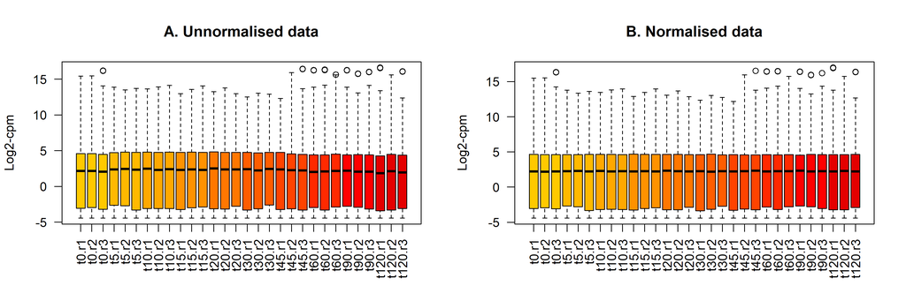

```r
Color <- c("#FFC900", "#FFB900","#FFA800", "#FF9200", "#FF7700","#FF5D00","#FF4300","#FF2900","#FF0000","#E40000")[as.factor(metadata$Time)]

par(mfrow=c(1,2))
# plot of unnormalised data
cldgList <- cpm(dgList, log=TRUE, prior.count = 1)
boxplot(cldgList, las=2, col=Color, main="")
title(main="A. Unnormalised data",ylab="Log2-cpm")

# plot of normalised data
cldgList2 <- cpm(dgList2, log=TRUE, prior.count = 1)
boxplot(cldgList2, las=2, col=Color, main="")
title(main="B. Normalised data",ylab="Log2-cpm")
```

Did you see the difference? (hint: compare the median and the upper quartile). From now on, we will work with normalized data.

## 4. Data transformation for visualization

Count data has a has a broad spectrum of distribution, from genes with zero count to genes with thousands.

Plot the following boxplots:

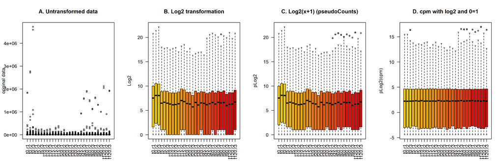

```r
par(mfrow=c(1,4)) #Figure2
boxplot(dgList$counts, las=2, col=as.matrix(Color), main="")
title(main="A. Untransformed data",ylab="original data")

Log2 <- log2(dgList2$counts)
Log2_pseudoCounts <- log2(dgList2$counts+1)
cpmCounts <- cpm(dgList2, log=TRUE, prior.count = 1)

boxplot(Log2, las=2, col=as.matrix(Color), main="")
title(main="B. Log2 transformation",ylab="Log2")

boxplot(Log2_pseudoCounts, las=2, col=as.matrix(Color), main="")
title(main="C. Log2(x+1) (pseudoCounts)",ylab="pLog2")

boxplot(cpmCounts, las=2, col=as.matrix(Color), main="")
title(main="D. cpm with log2 and 0=1",ylab="pLog2(cpm)")
```

As you can see on panel A, the most datapoints are sticked to the x bar due that the majority of genes having low count values. A way to “see all the datapoints” is to apply a data transformation. In panel B, a log2 transformation was applied. However, since log2 function can’t deal with “zero” counts, those samples are lost in the graph. This is not a problem in a boxplot representation but could be a problem for scatter plots or density plots.

A trick to avoid this issue is to add 1 count to all samples. This is known as “pseudocount” transformation, which is applied in panel C.

Panel D shows cpm transformation, which is another kind of data manipulation, where data is divided by the total number of counts and normalized by 1 million. cpm(x) = (x/sum(x))*1000000. Then, “only zeros” are transformed to 1 (0=1) and log2 transformation can be applied.

We can check the distribution of a specific sample using the *hist* function;

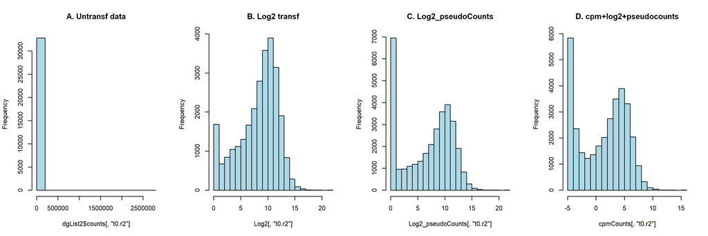

```r
par(mfrow=c(1,4))
hist(dgList2$counts[,"t0.r2"],col="lightblue", main="A. Untransf data")
hist(Log2[,"t0.r2"],col="lightblue", main="B. Log2 transf")
hist(Log2_pseudoCounts[,"t0.r2"],col="lightblue", main="C. Log2_pseudoCounts")
hist(cpmCounts[,"t0.r2"],col="lightblue", main="D. cpm+log2+pseudocounts")
```

Take a look at the peak at zero, which is lost on the Log2 graph.

## 5. Gene filtering

How many genes are not expressed over all samples?

```r
kable(table(rowSums(dgList2$counts==0)==30))
```

| Var1 | Freq |
| --- | --- |
| FALSE | 29768 |
| TRUE | 3065 |

There are 32,833 genes in this dataset. However, many of them are not expressed or are not represented by enough reads to contribute to the analysis. Removing those genes means that we ultimately have fewer tests to perform, thereby reducing problems associated with multiple testing.

Here, we present two ways to do perform counts filtering.

### 5.1. Manual cutoff

We will retain only those genes that are represented by at least 1 cpm in at least two samples.

Calculate the cpm

```r
countsPerMillion <- cpm(dgList2)
```

Let’s compare pre and post cpm for the first sample

```r
summary(dgList2$counts[,1])
```

```
##    Min. 1st Qu.  Median    Mean 3rd Qu.    Max.
##       0       3     184    1258    1000 1840767
```

```r
summary(countsPerMillion[,1]) #first sample (t0.r1)
```

```
##     Min.  1st Qu.   Median     Mean  3rd Qu.     Max.
##     0.00     0.08     4.61    31.55    25.07 46143.64
```

What’s the difference?… Let’s found what cells of the matrix have a cpm count above 1

```r
countCheck <- countsPerMillion > 1
kable(head(countCheck))
```

|  | t0.r1 | t0.r2 | t0.r3 | t5.r1 | t5.r2 | t5.r3 | t10.r1 | t10.r2 | t10.r3 | t15.r1 | t15.r2 | t15.r3 | t20.r1 | t20.r2 | t20.r3 | t30.r1 | t30.r2 | t30.r3 | t45.r1 | t45.r2 | t45.r3 | t60.r1 | t60.r2 | t60.r3 | t90.r1 | t90.r2 | t90.r3 | t120.r1 | t120.r2 | … |
| --- | --- | --- | --- | --- | --- | --- | --- | --- | --- | --- | --- | --- | --- | --- | --- | --- | --- | --- | --- | --- | --- | --- | --- | --- | --- | --- | --- | --- | --- | --- |
| AT1G01010 | TRUE | TRUE | TRUE | TRUE | TRUE | TRUE | TRUE | TRUE | TRUE | TRUE | TRUE | TRUE | TRUE | TRUE | TRUE | TRUE | TRUE | TRUE | TRUE | TRUE | TRUE | TRUE | TRUE | TRUE | TRUE | TRUE | TRUE | TRUE | TRUE | … |
| AT1G01020 | TRUE | TRUE | TRUE | TRUE | TRUE | TRUE | TRUE | TRUE | TRUE | TRUE | TRUE | TRUE | TRUE | TRUE | TRUE | TRUE | TRUE | TRUE | TRUE | TRUE | TRUE | TRUE | TRUE | TRUE | TRUE | TRUE | TRUE | TRUE | TRUE | … |
| AT1G03987 | FALSE | FALSE | FALSE | FALSE | FALSE | FALSE | FALSE | FALSE | FALSE | FALSE | FALSE | FALSE | FALSE | FALSE | FALSE | FALSE | FALSE | FALSE | FALSE | FALSE | FALSE | FALSE | FALSE | FALSE | FALSE | FALSE | FALSE | FALSE | FALSE | … |
| AT1G01030 | TRUE | TRUE | TRUE | TRUE | TRUE | TRUE | TRUE | TRUE | TRUE | TRUE | TRUE | TRUE | TRUE | TRUE | TRUE | TRUE | TRUE | TRUE | TRUE | TRUE | TRUE | TRUE | TRUE | TRUE | TRUE | TRUE | TRUE | TRUE | TRUE | … |
| AT1G01040 | TRUE | TRUE | TRUE | TRUE | TRUE | TRUE | TRUE | TRUE | TRUE | TRUE | TRUE | TRUE | TRUE | TRUE | TRUE | TRUE | TRUE | TRUE | TRUE | TRUE | TRUE | TRUE | TRUE | TRUE | TRUE | TRUE | TRUE | TRUE | TRUE | … |
| AT1G03993 | TRUE | TRUE | TRUE | TRUE | TRUE | TRUE | TRUE | TRUE | TRUE | TRUE | TRUE | TRUE | TRUE | TRUE | TRUE | TRUE | TRUE | TRUE | TRUE | TRUE | TRUE | TRUE | TRUE | TRUE | TRUE | TRUE | TRUE | TRUE | TRUE | … |

Now, sum the “TRUE” values across rows to keep only the ones where at least 2 cells have 1 cpm value

```r
keep <- which(rowSums(countCheck) >= 2) # over 1 cpm
str(keep)
```

```
##  Named int [1:22043] 1 2 4 5 6 7 8 10 11 13 ...
##  - attr(*, "names")= chr [1:22043] "AT1G01010" "AT1G01020" "AT1G01030" "AT1G01040" ...
```

Apply the filter to the normalized edgeR table and save the result to a new edgeR object

```r
dgList3 <- dgList2[keep,, keep.lib.sizes=FALSE]
```

Compare the dimensions of original and filtered edgeR data:

```r
dim(dgList2)
```

```
## [1] 32833    30
```

```r
dim(dgList3)
```

```
## [1] 22043    30
```

Now, let’s compare all samples pre and post filtering with a density plot. The following lines produce a density of log-CPM values for (A) raw pre-filtered data and (B) post-filtered data for each sample.

Dotted vertical lines mark the log-CPM threshold that we use (cpm >1). Samples are colored by time as it is represented on the legend.

```r
nsamples <- ncol(dgList)
lcpm.cutoff <- log2(1)
```

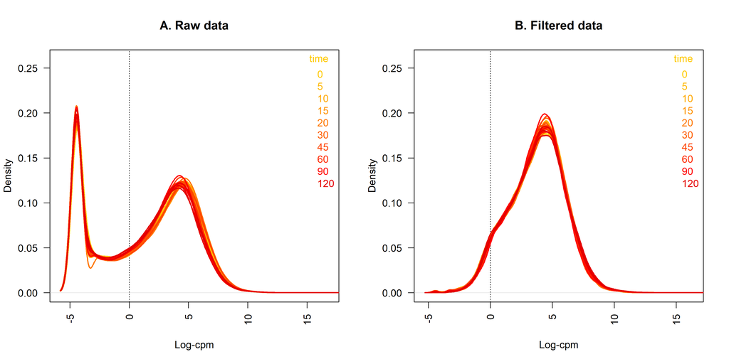

```r
par(mfrow=c(1,2))

z <- cpm(dgList, log=TRUE, prior.count=1)
plot(density(z[,1]), col=Color, lwd=2, ylim=c(0,0.26), las=2, main="", xlab="")
title(main="A. Raw data", xlab="Log-cpm")
abline(v=lcpm.cutoff, lty=3)
for (i in 2:nsamples){
  den <- density(z[,i])
  lines(den$x, den$y, col=Color[i], lwd=2)
}
legend("topright", title="time", unique(as.character(dgList$metadata$Time)), text.col=unique(Color), bty="n")

z <- cpm(dgList3, log=TRUE, prior.count=1)
plot(density(z[,1]), col=Color, lwd=2, ylim=c(0,0.26), las=2, main="", xlab="")
title(main="B. Filtered data", xlab="Log-cpm")
abline(v=lcpm.cutoff, lty=3)
for (i in 2:nsamples){
  den <- density(z[,i])
  lines(den$x, den$y, col=Color[i], lwd=2)
}
legend("topright", title="time", unique(as.character(dgList$metadata$Time)), text.col=unique(Color), bty="n")
```